# Phyloseq object generation

These are the scripts used to import the metabolomics and sequencing data from previous pipelines, and make phyloseq files for further analysis.

Load packages

```r
rm(list=ls()) #clear workspace

#library(dada2)
library(phyloseq)
library(vegan)
library(ggplot2)
library(ade4)
library(magrittr)
library(dplyr)
library(reshape2)
library(ape)
```

Load full metadata file and name by samples

```r
metadata_full <- read.delim("metadata.txt", header = T, sep = "") ## load metadata file

rownames(metadata_full) <-metadata_full$sample_name
```

###For LC-MS/MS metabolomics

Import the MZmine output.

```r
## read peak features table (csv file from Mzmine):
metab_table_full <- read.delim("Data_for_import/lcms-mzmine_quant.txt", header = TRUE, check.names=F, row.names=1)

#Give names to the peak features and trim table to only include peak areas

feature_names <-round(metab_table_full[,1:2], digits=3)
feature_names$concatenate <- paste0(1:nrow(feature_names),"_",feature_names[,1],"_",feature_names[,2])

metab_table <- metab_table_full[ ,grepl("Peak area", names(metab_table_full))] ### take only columns of "Peak area"
StrSplitList <- strsplit(colnames(metab_table), split = " ") ### cut out "Peak area"
colnames(metab_table) <- matrix(unlist(StrSplitList), nrow = length(StrSplitList), byrow = T)[,1] ### give new names for columns
rownames(metab_table) <-feature_names$concatenate
dim(metab_table)
```

```
[1] 19855   143
```

Trim the metadata to the polar LC-MS files only

```r
metadata <- metadata_full
metadata <- metadata[!is.na(metadata$File_polar), ]
```

```r
metab_table <- metab_table[,match(metadata$File_polar, colnames(metab_table))] ## sort table columns by metadata order (takes only samples listed in metadata!)
metab_table <- t(metab_table)
rownames(metab_table) <- metadata$sample_name ##Give the samples more informative names

rownames(metab_table)
```

```
  [1] "Af_elephant_1"        "Af_elephant_2"        "Af_elephant_3"        "As_elephant_1"        "As_elephant_2"
  [6] "As_elephant_3"        "As_elephant_4"        "As_elephant_5"        "Black_bear_1"         "Black_bear_2"
 [11] "Brown_bear_1"         "Brown_bear_2"         "Brown_bear_3"         "Brown_bear_4"         "Brown_bear_5"
 [16] "Capuchin_1"           "Chimpanzee_1"         "Chimpanzee_10"        "Chimpanzee_11"        "Chimpanzee_12"
 [21] "Chimpanzee_13"        "Chimpanzee_4"         "Chimpanzee_5"         "Chimpanzee_6"         "Chimpanzee_7"
 [26] "Chimpanzee_9"         "Coati_1"              "Coati_3"              "Coati_4"              "Coati_5"
 [31] "Coati_6"              "Coati_7"              "Coati_8"              "Donkey_1"             "Gibbon_1"
 [36] "Gibbon_2"             "Gibbon_3"             "Goat_1"               "Gorilla_1"            "Gorilla_2"
 [41] "Gorilla_3"            "Gorilla_4"            "Gorilla_5"            "Gorilla_6"            "Hyena_1"
 [46] "Jungle_cat_1"         "Jungle_cat_2"         "Lemur_1"              "Lemur_2"              "Leopard_1"
 [51] "Leopard_2"            "Lion_1"               "Lion_2"               "Lion_3"               "Mandarill_1"
 [56] "Mandarill_2"          "Mandarill_3"          "Mandarill_4"          "Mandarill_5"          "Mandarill_6"
 [61] "Mandarill_7"          "Mandarill_8"          "Rhino_1"              "Rhino_10"             "Rhino_11"
 [66] "Rhino_12"             "Rhino_13"             "Rhino_2"              "Rhino_3"              "Rhino_4"
 [71] "Rhino_5"              "Rhino_6"              "Rhino_7"              "Rhino_8"              "Rhino_9"
 [76] "Sand_cat_1"           "Sheep_1"              "Sheep_2"              "Sheep_3"              "Sheep_4"
 [81] "Sheep_5"              "Tiger_1"              "Tiger_2"              "Wolf_1"               "Wolf_2"
 [86] "Zebra_1"              "Zebra_10"             "Zebra_11"             "Zebra_12"             "Zebra_13"
 [91] "Zebra_14"             "Zebra_15"             "Zebra_16"             "Zebra_2"              "Zebra_3"
 [96] "Zebra_4"              "Zebra_5"              "Zebra_6"              "Zebra_7"              "Zebra_8"
[101] "Zebra_9"              "Cauliflower_leaves"   "Yellow_bell_pepper"   "Cattle_mix_pellets"   "Cauliflower_floret"
[106] "Eggplant"             "Cucumber"             "Watermelon"           "Beets"                "Wheat_straw"
[111] "Hardboiled_egg_yolk"  "Chicken"              "Cabbage"              "Vicia_straw"          "Red_bell_pepper"
[116] "Zucchini"             "Mealworm"             "Lettuce"              "Melon"                "Alfalfa_straw"
[121] "Birds_mix_pellet"     "Peanuts"              "Persimmon"            "Green_apple"          "Oats_straw"
[126] "Bonzo_pellets"        "Sweet_potato"         "Beef"                 "Mouse"                "Tomato"
[131] "Kohlrabi"             "Fennel"               "Fish"                 "Hardboiled_egg_white" "Banana"
[136] "QC_2"                 "QC_3"                 "QC_4"                 "Bkgrnd_1_food"        "Bkgrnd_2_food"
[141] "Bkgrnd_feces"         "Blank_feces-MeOH"     "Blank_food-MeOH"
```

Open the GNPS polar output, and give the rownames new peak feature names

```r
GNPS_full <- read.delim("Data_for_import/lcms-GNPS_ID_file.txt", header = T, sep = "") ## load metadata file

dim(GNPS_full)
```

```
[1] 19855    36
```

```r
rownames(GNPS_full) <-feature_names$concatenate

#Check the end of the file manually to make sure no lines were skipped
tail(GNPS_full, n=5)
```

|  | ATTRIBUTE_SampleType | GNPSGROUP.Bear | GNPSGROUP.Blank | GNPSGROUP.Capuchin | GNPSGROUP.Carnivore | GNPSGROUP.CarnivorousCat | GNPSGROUP.Chimp | GNPSGROUP.Coati | GNPSGROUP.Donkey | GNPSGROUP.Elephant | GNPSGROUP.Feces | GNPSGROUP.Food | GNPSGROUP.Gibbon | GNPSGROUP.Goat | GNPSGROUP.Gorilla | GNPSGROUP.Herbivore | GNPSGROUP.Lemur | GNPSGROUP.Mandrill | GNPSGROUP.Meat | GNPSGROUP.Omnivore | GNPSGROUP.Plants | GNPSGROUP.QC | GNPSGROUP.Rhino | GNPSGROUP.Sheep | GNPSGROUP.Wolf | GNPSGROUP.Zebra | LibraryID | MQScore | RTConsensus | … |
| --- | --- | --- | --- | --- | --- | --- | --- | --- | --- | --- | --- | --- | --- | --- | --- | --- | --- | --- | --- | --- | --- | --- | --- | --- | --- | --- | --- | --- | --- | --- |
| 19851_289.162_1.826 | Food | 0 | 0.000000000 | 0 | 0 | 0 | 0 | 0 | 0 | 0 | 0 | 0.000004440 | 0 | 0 | 0 | 0 | 0 | 0 | 0.00002000 | 0 | 0.00e+00 | 0 | 0 | 0 | 0 | 0 | N/A | N/A | 1.8256 | … |
| 19852_148.977_1.768 | Blank,Food | 0 | 0.002257932 | 0 | 0 | 0 | 0 | 0 | 0 | 0 | 0 | 0.000034700 | 0 | 0 | 0 | 0 | 0 | 0 | 0.00000702 | 0 | 3.88e-05 | 0 | 0 | 0 | 0 | 0 | N/A | N/A | 1.7682 | … |
| 19853_186.124_0.924 | Food | 0 | 0.000000000 | 0 | 0 | 0 | 0 | 0 | 0 | 0 | 0 | 0.000003010 | 0 | 0 | 0 | 0 | 0 | 0 | 0.00000726 | 0 | 1.94e-06 | 0 | 0 | 0 | 0 | 0 | N/A | N/A | 0.9237 | … |
| 19854_441.246_2.064 | Food | 0 | 0.000000000 | 0 | 0 | 0 | 0 | 0 | 0 | 0 | 0 | 0.000175616 | 0 | 0 | 0 | 0 | 0 | 0 | 0.00078609 | 0 | 1.29e-06 | 0 | 0 | 0 | 0 | 0 | N/A | N/A | 2.0638 | … |
| 19855_447.22_1.443 | Food | 0 | 0.000000000 | 0 | 0 | 0 | 0 | 0 | 0 | 0 | 0 | 0.000005490 | 0 | 0 | 0 | 0 | 0 | 0 | 0.00002470 | 0 | 0.00e+00 | 0 | 0 | 0 | 0 | 0 | N/A | N/A | 1.4435 | … |

```r
NA
NA
```

Make subsets for peak features only appearing in feces or only in food. This is based on the cutoff set for the peak area in MZmine

```r
GNPS_fecal <- t(subset(GNPS_full, ATTRIBUTE_SampleType == "Feces"))
GNPS_food <- t(subset(GNPS_full, ATTRIBUTE_SampleType == "Food"))
GNPS_dietder <- t(subset(GNPS_full, ATTRIBUTE_SampleType == "Feces,Food"))

dim(GNPS_fecal)
```

```
[1]    36 10029
```

```r
dim(GNPS_food)
```

```
[1]   36 2319
```

```r
dim(GNPS_dietder)
```

```
[1]   36 4034
```

Normalization by internal standard, ampicillin. This peak feature was found based on its mass and rt of 350.11 and approximately 2.93 minutes, and is the first peak feature of the output.

```r
metadata$int.std <- metab_table[,1]
##The methanol blanks did not contain any ISTD. I manually added in a value based on the averages of the fecal and food samples respectively, just to get a ballpark figure for the relative peak intensities there.

##Look at the distribution of the internal standard values
range(metadata$int.std)
```

```
[1] 6.06e+07 2.33e+08
```

```r
mean(metadata$int.std)
```

```
[1] 159548252
```

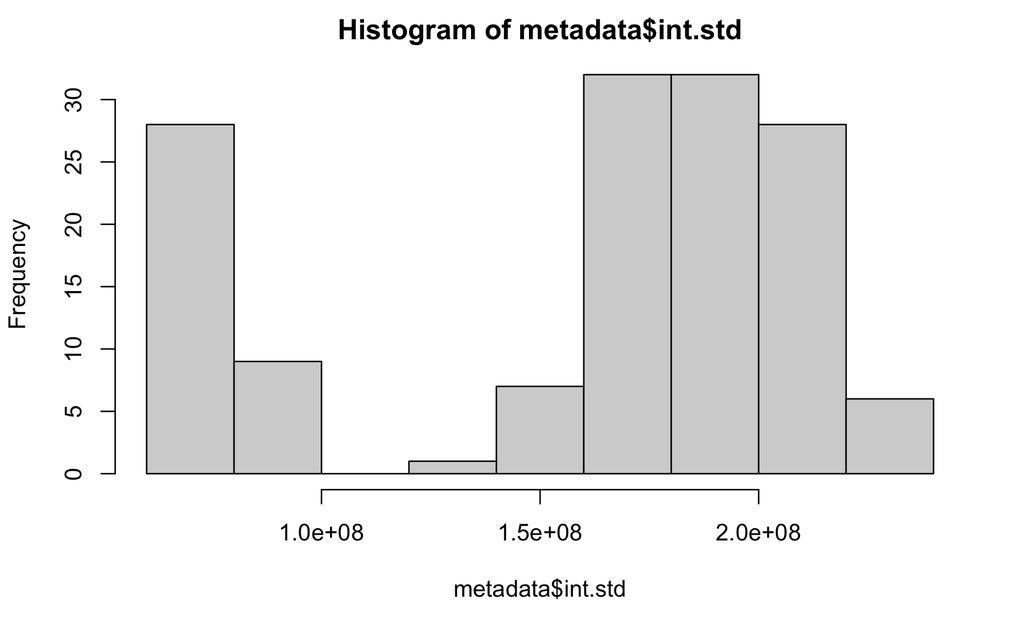

```r
hist(metadata$int.std)
```

```r
metab_table_norm <- sweep(metab_table, MARGIN=1, metadata$int.std, FUN="/") ##divide by ISTD for normalization

##Check that worked as anticipated
metab_table_norm[,1]
```

```
       Af_elephant_1        Af_elephant_2        Af_elephant_3        As_elephant_1        As_elephant_2
                   1                    1                    1                    1                    1
       As_elephant_3        As_elephant_4        As_elephant_5         Black_bear_1         Black_bear_2
                   1                    1                    1                    1                    1
        Brown_bear_1         Brown_bear_2         Brown_bear_3         Brown_bear_4         Brown_bear_5
                   1                    1                    1                    1                    1
          Capuchin_1         Chimpanzee_1        Chimpanzee_10        Chimpanzee_11        Chimpanzee_12
                   1                    1                    1                    1                    1
       Chimpanzee_13         Chimpanzee_4         Chimpanzee_5         Chimpanzee_6         Chimpanzee_7
                   1                    1                    1                    1                    1
        Chimpanzee_9              Coati_1              Coati_3              Coati_4              Coati_5
                   1                    1                    1                    1                    1
             Coati_6              Coati_7              Coati_8             Donkey_1             Gibbon_1
                   1                    1                    1                    1                    1
            Gibbon_2             Gibbon_3               Goat_1            Gorilla_1            Gorilla_2
                   1                    1                    1                    1                    1
           Gorilla_3            Gorilla_4            Gorilla_5            Gorilla_6              Hyena_1
                   1                    1                    1                    1                    1
        Jungle_cat_1         Jungle_cat_2              Lemur_1              Lemur_2            Leopard_1
                   1                    1                    1                    1                    1
           Leopard_2               Lion_1               Lion_2               Lion_3          Mandarill_1
                   1                    1                    1                    1                    1
         Mandarill_2          Mandarill_3          Mandarill_4          Mandarill_5          Mandarill_6
                   1                    1                    1                    1                    1
         Mandarill_7          Mandarill_8              Rhino_1             Rhino_10             Rhino_11
                   1                    1                    1                    1                    1
            Rhino_12             Rhino_13              Rhino_2              Rhino_3              Rhino_4
                   1                    1                    1                    1                    1
             Rhino_5              Rhino_6              Rhino_7              Rhino_8              Rhino_9
                   1                    1                    1                    1                    1
          Sand_cat_1              Sheep_1              Sheep_2              Sheep_3              Sheep_4
                   1                    1                    1                    1                    1
             Sheep_5              Tiger_1              Tiger_2               Wolf_1               Wolf_2
                   1                    1                    1                    1                    1
             Zebra_1             Zebra_10             Zebra_11             Zebra_12             Zebra_13
                   1                    1                    1                    1                    1
            Zebra_14             Zebra_15             Zebra_16              Zebra_2              Zebra_3
                   1                    1                    1                    1                    1
             Zebra_4              Zebra_5              Zebra_6              Zebra_7              Zebra_8
                   1                    1                    1                    1                    1
             Zebra_9   Cauliflower_leaves   Yellow_bell_pepper   Cattle_mix_pellets   Cauliflower_floret
                   1                    1                    1                    1                    1
            Eggplant             Cucumber           Watermelon                Beets          Wheat_straw
                   1                    1                    1                    1                    1
 Hardboiled_egg_yolk              Chicken              Cabbage          Vicia_straw      Red_bell_pepper
                   1                    1                    1                    1                    1
            Zucchini             Mealworm              Lettuce                Melon        Alfalfa_straw
                   1                    1                    1                    1                    1
    Birds_mix_pellet              Peanuts            Persimmon          Green_apple           Oats_straw
                   1                    1                    1                    1                    1
       Bonzo_pellets         Sweet_potato                 Beef                Mouse               Tomato
                   1                    1                    1                    1                    1
            Kohlrabi               Fennel                 Fish Hardboiled_egg_white               Banana
                   1                    1                    1                    1                    1
                QC_2                 QC_3                 QC_4        Bkgrnd_1_food        Bkgrnd_2_food
                   1                    1                    1                    1                    1
        Bkgrnd_feces     Blank_feces-MeOH      Blank_food-MeOH
                   1                    1                    1
```

```r
metab_table <- metab_table_norm



#remove any peak features that are zero in all samples

metab_table2 <- metab_table[, colSums(metab_table) > 0]
dim(metab_table2)
```

```
[1]   143 19855
```

```r
##log transform all values log(x+1)


metab_table2 <- metab_table2+1

metab_table2 <- log(metab_table2)
```

Make phyloseq object

```r
ps_polar_all <- phyloseq(otu_table(metab_table2, taxa_are_rows=F),
               sample_data(metadata))

ps_polar_all
```

```
phyloseq-class experiment-level object
otu_table()   OTU Table:         [ 19855 taxa and 143 samples ]
sample_data() Sample Data:       [ 143 samples by 25 sample variables ]
```

```r
#saveRDS(ps_polar_all, "ps_polar_all.rds")
```

Subset to only fecal samples

```r
metadata <- subset(metadata, Type=="Feces")
metadata <- droplevels(metadata)

##first take only fecal samples, not food
metab_fecal <- metab_table2[match(metadata$sample_name, rownames(metab_table2)),]
dim(metab_fecal)
```

```
[1]   101 19855
```

```r
metab_fecal2 <- metab_fecal[, colSums(metab_fecal) > 0]
dim(metab_fecal2)
```

```
[1]   101 16295
```

Make phyloseq object for fecal samples with all peak features (including those that appear in dietary samples)

```r
ps_polar_feces_all <- phyloseq(otu_table(metab_fecal2, taxa_are_rows=F),
               sample_data(metadata))

ps_polar_feces_all
```

```
phyloseq-class experiment-level object
otu_table()   OTU Table:         [ 16295 taxa and 101 samples ]
sample_data() Sample Data:       [ 101 samples by 25 sample variables ]
```

```r
#saveRDS(ps_polar_feces_all, "ps_polar_feces_all.rds")
```

Now take only peak features that appear in the feces and not the dietary samples. This is the file that was used for the analyses in the paper.

```r
metab_fecal <- metab_fecal[,match(colnames(GNPS_fecal), colnames(metab_fecal))]

dim(metab_fecal)
```

```
[1]   101 10029
```

```r
ps_pol <- phyloseq(otu_table(metab_fecal, taxa_are_rows=F),
               sample_data(metadata))
ps_pol
```

```
phyloseq-class experiment-level object
otu_table()   OTU Table:         [ 10029 taxa and 101 samples ]
sample_data() Sample Data:       [ 101 samples by 25 sample variables ]
```

```r
#saveRDS(ps_pol, "ps_pol.rds")
```

###For 16S results

The sequencing files were processed using the DADA2 pipeline as detailed in the methods, according to the DADA2 tutorial, resulting in this abundance table. Taxonomy was assigned using SILVA.

```r
##Load abundance table
asv_abundance <- readRDS("Data_for_import/seqtab_nochim_101samples.RDS")

##Drop all ASVs with an abundance of fewer than 3 reads
asv_abundance <- asv_abundance[,colSums(asv_abundance)>3]
dim(asv_abundance)
```

```
[1]  101 8153
```

```r
##Load taxonomy table
load(file = "Data_for_import/taxa.RData")
dim(taxa)
```

```
[1] 9515    7
```

```r
rownames(taxa)[1:5]
```

```
[1] "TACGTAGGTCCCGAGCGTTGTCCGGATTTATTGGGCGTAAAGCGAGCGCAGGCGGTTTAA…"
[2] "TACGTATGTCGCAAGCGTTATCCGGATTTATTGGGCGTAAAGCGCGTCTAGGCGGTTTGG…"
[3] "TACGTAGGTGGCGAGCGTTATCCGGATTTACTGGGCGTAAAGGGAGCGTAGGCGGATGAT…"
[4] "TACGTAGGTGGCGAGCGTTGTCCGGATTTACTGGGCGTAAAGGGAGCGTAGGCGGACTTT…"
[5] "TACGTAGGTCCCGAGCGTTGTCCGGATTTATTGGGCGTAAAGCGAGCGCAGGCGGTTTAA…"
```

```r
##Subset to just relevant samples
taxa <- taxa[which(rownames(taxa) %in% colnames(asv_abundance)),]
dim(taxa)
```

```
[1] 8153    7
```

```r
dim(asv_abundance)
```

```
[1]  101 8153
```

```r
##Load tree file, which was created from ASV sequences using FastTree
tree <- read.tree("Data_for_import/asv_seqs.tre")

##Trim metadata to just fecal samples

metadata <- subset(metadata_full, Type=="Feces")

## Generating phyloseq object

setdiff(rownames(taxa),colnames(asv_abundance))
```

```
character(0)
```

```r
##Change names to a numbered index to match tree tips. The order is the same since all files were generated together.
rownames(taxa) <- 1:nrow(taxa)
colnames(asv_abundance) <- 1:ncol(asv_abundance)
ps_asv <- phyloseq(otu_table(asv_abundance, taxa_are_rows = FALSE),tax_table(taxa),sample_data(metadata),phy_tree(tree))

#saveRDS(ps_asv,"ps_asv.RDS")
```

###For GCMS

```r
##GNPS output file

metab_table_full <- read.delim("Data_for_import/gcms-GNPS_quant.txt", header = TRUE, check.names=F, row.names=1)

dim(metab_table_full)
```

```
[1] 1282  176
```

```r
metab_table <- metab_table_full

##Features were filtered based on the balance scores from a separate file from GNPS. This file was already filtered to only include balance scores of at least 50
balance_filter <- read.csv("Data_for_import/gcms-balance-scores.csv", header = TRUE, check.names=F, row.names=1)

metab_table <- metab_table[match(rownames(balance_filter),rownames(metab_table)),]

dim(metab_table)
```

```
[1] 407 176
```

Give names to the metabolites and cut out peak areas from metab table

```r
##make names using balance filter sheet
balance_filter$concatenate<-paste0(rownames(balance_filter),"_RT",balance_filter[,1],"_BAL",balance_filter[,2])

metab_table <- metab_table[ ,grepl("Peak area", names(metab_table))] ### take only columns of "Peak area"
StrSplitList <- strsplit(colnames(metab_table), split = " ") ### cut out "Peak area"
colnames(metab_table) <- matrix(unlist(StrSplitList), nrow = length(StrSplitList), byrow = T)[,1] ### give new names for columns

rownames(metab_table) <-balance_filter$concatenate
```

Limit the metadata to the GCMS files and give informative sample names

```r
metadata <- metadata_full[metadata_full$File_GCMS %in% colnames(metab_table),]

metadata <- droplevels(metadata)

metab_table <- t(metab_table)
rownames(metab_table) <- metadata$sample_name ##Give the samples more informative names

dim(metab_table)
```

```
[1] 174 407
```

```r
range(metab_table)
```

```
[1]          0 1031676509
```

Normalization by ISTD, ribitol. This was externally identified to be peak feature 483, with an RT of 20.1 min

```r
metadata$int.std <- metab_table[,"483_RT20.1_BAL100"]


range(metadata$int.std)
```

```
[1]   367801.5 11995509.8
```

```r
mean(metadata$int.std)
```

```
[1] 3622573
```

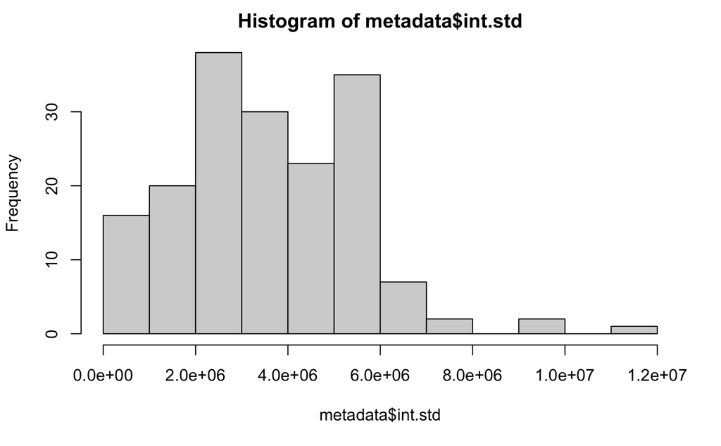

```r
hist(metadata$int.std)
```

```r
metab_table_norm <- sweep(metab_table, MARGIN=1, metadata$int.std, FUN="/") ##divide by ISTD for normalization

##check
metab_table_norm[,10]
```

```
       Af_elephant_1        Af_elephant_2        Af_elephant_3        As_elephant_1        As_elephant_2
          0.12201667           0.09704389           0.09145348           0.11555030           0.10863881
       As_elephant_3        As_elephant_4        As_elephant_5         Black_bear_1         Black_bear_2
          0.08708152           0.03890983           0.09820146           0.14037928           0.08542753
        Brown_bear_1         Brown_bear_2         Brown_bear_3         Brown_bear_4         Brown_bear_5
          0.11672891           0.09142949           0.12415840           0.08803992           0.07908953
          Capuchin_1         Chimpanzee_1        Chimpanzee_10        Chimpanzee_11        Chimpanzee_12
          0.09186679           0.10372559           0.09695538           0.11014105           0.10880783
       Chimpanzee_13         Chimpanzee_4         Chimpanzee_5         Chimpanzee_6         Chimpanzee_7
          0.09437993           0.10751675           0.10919003           0.09021452           0.07174819
        Chimpanzee_9              Coati_1              Coati_3              Coati_4              Coati_5
          0.46715215           0.11683191           0.17574231           0.08500035           0.12320988
             Coati_6              Coati_7              Coati_8             Donkey_1             Gibbon_1
          0.08090274           0.10479852           0.27205824           0.08594408           0.11223638
            Gibbon_2             Gibbon_3               Goat_1            Gorilla_1            Gorilla_2
          0.63870814           0.09180509           0.07853544           0.14452239           0.10335435
           Gorilla_3            Gorilla_4            Gorilla_5            Gorilla_6              Hyena_1
          0.13398641           0.28563713           0.01206496           0.06455199           0.06118480
        Jungle_cat_1         Jungle_cat_2              Lemur_1              Lemur_2            Leopard_1
          0.20423725           0.22662612           0.09580651           0.05816370           0.11759410
           Leopard_2               Lion_1               Lion_2               Lion_3          Mandarill_1
          0.08050651           0.23804077           0.00000000           0.01253492           0.08872371
         Mandarill_2          Mandarill_3          Mandarill_4          Mandarill_5          Mandarill_6
          0.06296470           0.06340394           0.07343523           0.10607164           0.09357901
         Mandarill_7          Mandarill_8              Rhino_1             Rhino_10             Rhino_11
          0.16430666           0.10730781           0.11814974           0.08927247           0.11202186
            Rhino_12             Rhino_13              Rhino_2              Rhino_3              Rhino_4
          0.24691201           0.10149445           0.04842831           0.13746121           0.18966942
             Rhino_5              Rhino_6              Rhino_7              Rhino_8              Rhino_9
          0.06684928           0.11794460           0.12339075           0.08845886           0.09952252
          Sand_cat_1              Sheep_1              Sheep_2              Sheep_3              Sheep_4
          0.04814133           0.12813424           0.07904174           0.29690378           0.08515162
             Sheep_5              Tiger_1              Tiger_2               Wolf_1               Wolf_2
          0.12101963           0.05084947           0.10835053           0.18342054           0.05325081
             Zebra_1             Zebra_10             Zebra_11             Zebra_12             Zebra_13
          0.04758515           0.08765108           0.05735137           0.05419799           0.11703661
            Zebra_14             Zebra_15             Zebra_16              Zebra_2              Zebra_3
          0.09798892           0.14261771           0.05665962           0.22006746           0.09997271
             Zebra_4              Zebra_5              Zebra_6              Zebra_7              Zebra_8
          0.11990741           0.07041888           0.08290339           0.07236677           0.15433753
```

[output cut: 15 more lines]

```
          0.08380298           0.21938706           0.09876772           0.14304720           0.08100455
                QC_6                 QC_7                 QC_8                 QC_9                QC_10
          0.08328268           0.08804913           0.07483427           0.08264017           0.11947196
               QC_11                QC_12                QC_13                QC_14                QC_15
          0.02940006           0.16747965           0.07816586           0.11733812           0.03125630
               QC_16                QC_17                QC_18                QC_19                QC_20
          0.06997790           0.11431794           0.08960096           0.10492105           0.09249923
               QC_21                QC_22                QC_23                QC_24                QC_25
          0.14220953           0.07840353           0.08025634           0.04797232           0.07696422
               QC_26                QC_27        Bkgrnd_1_food        Bkgrnd_2_food             Alkane_1
          0.15557951           0.12572259           0.01444796           0.07519576           0.06428193
            Alkane_2             Alkane_3             Alkane_4             Alkane_5             Alkane_6
          0.02171175           0.04619064           0.05131146           0.06277883           0.04341096
            Alkane_7             Alkane_8             Alkane_9            Alkane_10
          0.04519760           0.05064638           0.05911059           0.04107498
```

```r
metab_table_norm[,"483_RT20.1_BAL100"]
```

```
       Af_elephant_1        Af_elephant_2        Af_elephant_3        As_elephant_1        As_elephant_2
                   1                    1                    1                    1                    1
       As_elephant_3        As_elephant_4        As_elephant_5         Black_bear_1         Black_bear_2
                   1                    1                    1                    1                    1
        Brown_bear_1         Brown_bear_2         Brown_bear_3         Brown_bear_4         Brown_bear_5
                   1                    1                    1                    1                    1
          Capuchin_1         Chimpanzee_1        Chimpanzee_10        Chimpanzee_11        Chimpanzee_12
                   1                    1                    1                    1                    1
       Chimpanzee_13         Chimpanzee_4         Chimpanzee_5         Chimpanzee_6         Chimpanzee_7
                   1                    1                    1                    1                    1
        Chimpanzee_9              Coati_1              Coati_3              Coati_4              Coati_5
                   1                    1                    1                    1                    1
             Coati_6              Coati_7              Coati_8             Donkey_1             Gibbon_1
                   1                    1                    1                    1                    1
            Gibbon_2             Gibbon_3               Goat_1            Gorilla_1            Gorilla_2
                   1                    1                    1                    1                    1
           Gorilla_3            Gorilla_4            Gorilla_5            Gorilla_6              Hyena_1
                   1                    1                    1                    1                    1
        Jungle_cat_1         Jungle_cat_2              Lemur_1              Lemur_2            Leopard_1
                   1                    1                    1                    1                    1
           Leopard_2               Lion_1               Lion_2               Lion_3          Mandarill_1
                   1                    1                    1                    1                    1
         Mandarill_2          Mandarill_3          Mandarill_4          Mandarill_5          Mandarill_6
                   1                    1                    1                    1                    1
         Mandarill_7          Mandarill_8              Rhino_1             Rhino_10             Rhino_11
                   1                    1                    1                    1                    1
            Rhino_12             Rhino_13              Rhino_2              Rhino_3              Rhino_4
                   1                    1                    1                    1                    1
             Rhino_5              Rhino_6              Rhino_7              Rhino_8              Rhino_9
                   1                    1                    1                    1                    1
          Sand_cat_1              Sheep_1              Sheep_2              Sheep_3              Sheep_4
                   1                    1                    1                    1                    1
             Sheep_5              Tiger_1              Tiger_2               Wolf_1               Wolf_2
                   1                    1                    1                    1                    1
             Zebra_1             Zebra_10             Zebra_11             Zebra_12             Zebra_13
                   1                    1                    1                    1                    1
            Zebra_14             Zebra_15             Zebra_16              Zebra_2              Zebra_3
                   1                    1                    1                    1                    1
             Zebra_4              Zebra_5              Zebra_6              Zebra_7              Zebra_8
                   1                    1                    1                    1                    1
```

[output cut: 15 more lines]

```
                   1                    1                    1                    1                    1
                QC_6                 QC_7                 QC_8                 QC_9                QC_10
                   1                    1                    1                    1                    1
               QC_11                QC_12                QC_13                QC_14                QC_15
                   1                    1                    1                    1                    1
               QC_16                QC_17                QC_18                QC_19                QC_20
                   1                    1                    1                    1                    1
               QC_21                QC_22                QC_23                QC_24                QC_25
                   1                    1                    1                    1                    1
               QC_26                QC_27        Bkgrnd_1_food        Bkgrnd_2_food             Alkane_1
                   1                    1                    1                    1                    1
            Alkane_2             Alkane_3             Alkane_4             Alkane_5             Alkane_6
                   1                    1                    1                    1                    1
            Alkane_7             Alkane_8             Alkane_9            Alkane_10
                   1                    1                    1                    1
```

```r
metab_table <- metab_table_norm

range(metab_table)
```

```
[1]   0.0000 849.3427
```

Set a cutoff for very small peak areas and log transform: log(x+1)

```r
metab_table2 <-metab_table

metab_table2[metab_table2<0.01] <- 0

metab_table2 <- metab_table2[, colSums(metab_table2) > 0] #remove any variables that are all zero

dim(metab_table2)
```

```
[1] 174 407
```

```r
metab_table2 <- metab_table2+1

metab_table2 <- log(metab_table2)

metab_table <- metab_table2
```

Make PS object with all samples

```r
ps_gcms_all <- phyloseq(otu_table(metab_table, taxa_are_rows=F),
               sample_data(metadata))


#saveRDS(ps_gcms_all, "ps_gcms_all.rds")
```

Make phyloseq object for fecal samples only

```r
ps_gcms <- subset_samples(ps_gcms_all, Type=="Feces")

##remove peak features which are zero in all fecal samples
feces <- as(otu_table(ps_gcms), "matrix")

feces <- feces[, colSums(feces) !=0]

metadata <- subset(metadata, Type=="Feces")
metadata <- droplevels(metadata)

##make sure sample order matches metadata order
feces <- feces[match(metadata$sample_name, rownames(feces)),]

ps_gcms <- phyloseq(otu_table(feces, taxa_are_rows=F),
               sample_data(metadata))
```

Which peaks appear only in dietary compounds?

```r
ps <- subset_samples(ps_gcms_all, Type =="Food")
food <- as(otu_table(ps), "matrix")

ps <- subset_samples(ps_gcms_all , Type=="Feces")
feces <- as(otu_table(ps), "matrix")

ifood <- colSums(food) !=0
ifeces <- colSums(feces) !=0

foodnonzero <- food[, ifood]
foodzero <- food[, !ifood]

fecesnonzero <- feces[, ifeces]
feceszero <- feces[, !ifeces]

#Appears in feces but not food
setdiff(colnames(fecesnonzero),colnames(foodnonzero))
```

```
 [1] "1_RT2.84_BAL100"     "34_RT4.21_BAL75"     "218_RT10.56_BAL100"  "552_RT22.81_BAL56"   "663_RT27.72_BAL79"
 [6] "745_RT31.64_BAL100"  "815_RT33.64_BAL58"   "865_RT36.2_BAL58"    "903_RT37.42_BAL100"  "919_RT37.87_BAL50"
[11] "943_RT38.51_BAL61"   "945_RT38.57_BAL100"  "958_RT38.91_BAL87"   "965_RT38.98_BAL65"   "976_RT39.21_BAL56"
[16] "1105_RT43.91_BAL70"  "1107_RT43.98_BAL100" "1117_RT44.3_BAL60"
```

```r
#Appears in food but not feces
setdiff(colnames(foodnonzero),colnames(fecesnonzero))
```

```
 [1] "14_RT3.45_BAL89"     "18_RT3.74_BAL60"     "39_RT4.55_BAL100"    "44_RT4.77_BAL62"     "77_RT5.92_BAL67"
 [6] "95_RT6.45_BAL100"    "152_RT8.21_BAL100"   "157_RT8.42_BAL79"    "165_RT8.67_BAL100"   "166_RT8.71_BAL90"
[11] "170_RT9.01_BAL50"    "181_RT9.3_BAL82"     "187_RT9.62_BAL67"    "241_RT11.45_BAL100"  "269_RT12.33_BAL68"
[16] "271_RT12.45_BAL68"   "279_RT12.75_BAL61"   "287_RT12.97_BAL58"   "349_RT14.97_BAL55"   "364_RT15.53_BAL55"
[21] "395_RT16.76_BAL100"  "420_RT17.58_BAL56"   "507_RT21.23_BAL55"   "520_RT21.61_BAL70"   "527_RT21.91_BAL75"
[26] "532_RT22.18_BAL100"  "537_RT22.3_BAL53"    "573_RT24.05_BAL76"   "576_RT24.26_BAL55"   "581_RT24.41_BAL100"
[31] "584_RT24.58_BAL100"  "618_RT25.95_BAL50"   "619_RT25.99_BAL66"   "623_RT26.17_BAL58"   "650_RT27.28_BAL51"
[36] "652_RT27.35_BAL53"   "685_RT28.95_BAL100"  "727_RT31.05_BAL59"   "750_RT31.84_BAL55"   "778_RT32.54_BAL77"
[41] "798_RT33.17_BAL100"  "813_RT33.59_BAL85"   "830_RT34.38_BAL100"  "855_RT35.88_BAL100"  "1016_RT40.46_BAL100"
[46] "1017_RT40.49_BAL63"  "1019_RT40.57_BAL100" "1020_RT40.69_BAL77"  "1026_RT40.89_BAL89"  "1029_RT41.06_BAL100"
[51] "1035_RT41.42_BAL52"  "1044_RT41.72_BAL84"  "1070_RT42.55_BAL60"
```

###Ensure that sample order matches

Samples need to be all in the same order for the Mantel test comparisons. Make sure that they are before continuing using match.

```r
asv <- as(otu_table(ps_asv), "matrix")
pol <- as(otu_table(ps_pol), "matrix")
gcms <- as(otu_table(ps_gcms), "matrix")

metadata <-subset(metadata_full, Type=="Feces")
metadata <- droplevels(metadata)

match(metadata$sample_name, rownames(pol))
```

```
  [1]   1   2   3   4   5   6   7   8   9  10  11  12  13  14  15  16  17  18  19  20  21  22  23  24  25  26  27  28  29
 [30]  30  31  32  33  34  35  36  37  38  39  40  41  42  43  44  45  46  47  48  49  50  51  52  53  54  55  56  57  58
 [59]  59  60  61  62  63  64  65  66  67  68  69  70  71  72  73  74  75  76  77  78  79  80  81  82  83  84  85  86  87
 [88]  88  89  90  91  92  93  94  95  96  97  98  99 100 101
```

```r
match(metadata$sample_name, rownames(asv))
```

```
  [1]   1   2   3   4   5   6   7   8   9  10  11  12  13  14  15  16  17  18  19  20  21  22  23  24  25  26  27  28  29
 [30]  30  31  32  33  34  35  36  37  38  39  40  41  42  43  44  45  46  47  48  49  50  51  52  53  54  55  56  57  58
 [59]  59  60  61  62  63  64  65  66  67  68  69  70  71  72  73  74  75  76  77  78  79  80  81  82  83  84  85  86  87
 [88]  88  89  90  91  92  93  94  95  96  97  98  99 100 101
```

```r
match(metadata$sample_name, rownames(gcms))
```

```
  [1]   1   2   3   4   5   6   7   8   9  10  11  12  13  14  15  16  17  18  19  20  21  22  23  24  25  26  27  28  29
 [30]  30  31  32  33  34  35  36  37  38  39  40  41  42  43  44  45  46  47  48  49  50  51  52  53  54  55  56  57  58
 [59]  59  60  61  62  63  64  65  66  67  68  69  70  71  72  73  74  75  76  77  78  79  80  81  82  83  84  85  86  87
 [88]  88  89  90  91  92  93  94  95  96  97  98  99 100 101
```